```python
import pandas as pd
from IPython.display import Image
```

# Sales forecasting & Media Impact Analysis.

### Abstract

This project was made for the challenge promoted by Fater S.p.A. about forecasting sales with time series data, using Machine Learning and other modern methods. This Challenge was addressed to the students of the Master of Science on Data Science at University Federico II of Naples. The challenge has two main goals: First, build a model to obtain the best Tampax sales volume estimate by week and by product Stock Keeping Unit for the total Italian market for the semester April 2019 to September 2019. Second, build a model to understand the impact of seasonality, media and promos on Tampax Sell Out Volumes. To achieve the best possible results, three different methods were applied: Vector Autoregression, Sarimax and Long Short-Term Memory. Each of these methods yielded different results.

### Introduction

Tampons are a feminine hygiene product designed to absorb the menstrual flow together with the pads and menstrual cups. In Italy, Tampax, a brand owned by Fater S.p.A., owns 68% of the value share. The company is the leader in Italy for hygiene and home products, often launching social initiatives and campaigns like “#decidoio”, aiming to remove taboos related to using tampons. The company also teams with female athletes and professionists to promote the freedom of choice of women. As of now, the Italian market of tampons is divided in two segments: with applicator, more hygienic and easier to use and without applicator, practical to bring as spare. For the Tampax brand, there are several products on the market: Blue Box, with a paper applicator, the most successful one according to the datasets, Compak, with a compact applicator, Tampax&Go, designed for the comfort and the easy application, Camomile, without applicator and Cotone, 100% cotton made. These products are strictly tied to the datasets given to us, as they all vary in terms in sales, popularity, promotions and innovation. Each product showed different behaviors when analyzed with our models.

### Datasets

#### Historical Series Tampons:

The core dataset, containing time series of sales from January 2017 to March 2019. The dataset contains: Data Rif: Date in which the product was sold to the distributor. Category: Aggregation of segments that groups the products that cover the same need. Segment: Aggregation of SKU (Stock Keeping Unit) based on product distinctive features. Product: Single Stock Keeping Unit Customer: Italian distributor who sells our product to the final consumer. Standard Units: Daily volumes sold from Fater to the distributors (sell-in). Regione, Provincia, Channel: Geographical informations about the distributors.

```python
time_series_tampons = pd.read_csv("historical_series_tampons_NEW.csv", sep=";")
time_series_tampons.head(5)
```

|  | Data Rif | Category | Segment | Products | Customers | Regione | Provincia | Channel | Standard Units |
| --- | --- | --- | --- | --- | --- | --- | --- | --- | --- |
| 0 | 03/01/2017 | Tamponi | Blue Box | Product 1 | Customer 82 | Veneto | PD | DRUGSTORE | 204 |
| 1 | 03/01/2017 | Tamponi | Blue Box | Product 1 | Customer 113 | Lombardia | BG | GD | 17 |
| 2 | 03/01/2017 | Tamponi | Blue Box | Product 3 | Customer 43 | Trentino Alto Adige | TN | DO | 28 |
| 3 | 03/01/2017 | Tamponi | Blue Box | Product 3 | Customer 82 | Veneto | PD | DRUGSTORE | 588 |
| 4 | 03/01/2017 | Tamponi | Blue Box | Product 4 | Customer 30 | Piemonte | NO | GD | 24 |

#### Tampons Historical Promo:

Contains past periods of promos for each product. Its variables are: Customer: Italian distributor who sells our product to the final consumer. Segment: Aggregation of SKU (Stock Keeping Unit) based on product distinctive features. Inizio Promo: Starting period of the historical promo. Fine Promo: Ending period of the historical promo.

```python
tampons_historical_promo = pd.read_csv("tampons_historical_promo_NEW.csv", sep=";")
tampons_historical_promo.head(5)
```

|  | Customer | Segment | Inizio Promo | Fine Promo |
| --- | --- | --- | --- | --- |
| 0 | Customer 104 | Blue Box | 12/02/2018 | 25/02/2018 |
| 1 | Customer 104 | Blue Box | 04/04/2018 | 22/04/2018 |
| 2 | Customer 104 | Blue Box | 14/05/2018 | 03/06/2018 |
| 3 | Customer 104 | Blue Box | 27/06/2018 | 15/07/2018 |
| 4 | Customer 104 | Blue Box | 27/08/2018 | 09/09/2018 |

#### Tampons Promo Planning:

Future promos planned for the semester between April 2019 and September 2019. Contains the same variables as “Tampons Historical Promo”, but the promos are planned and not historical.

```python
future_promo = pd.read_csv("tampons_promo_planning_NEW.csv", sep=";")
future_promo.head(5)
```

|  | Customer | Segment | Inizio Promo | Fine Promo |
| --- | --- | --- | --- | --- |
| 0 | Customer 105 | Blue Box | 30/04/2019 | 19/05/2019 |
| 1 | Customer 105 | Blue Box | 24/07/2019 | 11/08/2019 |
| 2 | Customer 105 | Blue Box | 25/09/2019 | 13/10/2019 |
| 3 | Customer 105 | Compak | 09/07/2019 | 21/07/2019 |
| 4 | Customer 105 | Tampax&Go | 09/07/2019 | 21/07/2019 |

#### List Increase Monthly:

Binary dataset, contains only two variables: Month: Month when the sales happened. List Increase: Binary variable, when equal to 1 shows the first month in which the distributor bought at an increased price compared to the month before.

```python
list_increase_monthly = pd.read_csv("list_increase_monthly.csv", sep=";")
list_increase_monthly.head(5)
```

|  | Month | List Increase |
| --- | --- | --- |
| 0 | gen-17 | 0 |
| 1 | feb-17 | 0 |
| 2 | mar-17 | 0 |
| 3 | apr-17 | 0 |
| 4 | mag-17 | 0 |

#### GRPs:

Gross Rating Products, measuring the size of media campaigns by week. Week: week in which the measure happened. Tampax GRPs: Measure of the size of the media campaign (net contacts / total target)

```python
GRP = pd.read_csv("tampax_GRPs.csv", sep=";")
GRP.head(5)
```

|  | Week | TAMPAX GRPs |
| --- | --- | --- |
| 0 | 07-gen-17 | NaN |
| 1 | 14-gen-17 | NaN |
| 2 | 21-gen-17 | NaN |
| 3 | 28-gen-17 | NaN |
| 4 | 04-feb-17 | NaN |

#### Volumes Sell Out:

Volumes sold, by week and by product, from distributors to final consumers (Sell-out sales). Week: Week in which the products were sold by the distributor. Market Products: All products that are sold in the market (Fater and competition). Volumes: Volumes sold from the distributors to the final consumer (sell-out).

```python
volumes_sell_out = pd.read_csv("volumes_sell_out_tampons.csv", sep=";")
volumes_sell_out.head(5)
```

|  | week | Market Products | Volumes |
| --- | --- | --- | --- |
| 0 | W 01/01/17 | TAMPONI Total | 11.381,40 |
| 1 | W 08/01/17 | TAMPONI Total | 12.115,50 |
| 2 | W 15/01/17 | TAMPONI Total | 12.648,00 |
| 3 | W 22/01/17 | TAMPONI Total | 11.981,50 |
| 4 | W 29/01/17 | TAMPONI Total | 11.593,30 |

### Cleaning

Some products, particularly Product 12, 14, 16, 17, 20, 21 and 22, were launched on the market very late compared to the beginning of the time series. These products yield very insignificant results and thus we decided to drop them. Here is a look on some of those products:

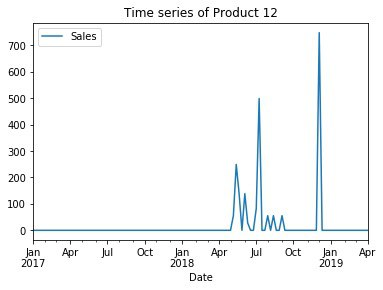

```python
Image(filename='image1.jpg')
```

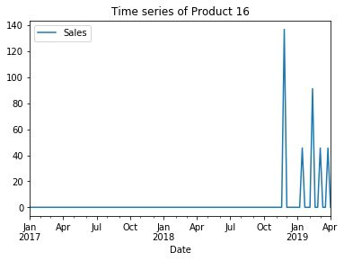

```python
Image(filename='image2.jpg')
```

### The models

Sarimax and LSTM were used only to accomplish the first goal of the challenge, instead VAR can be applied both to the first and second goal. Here is a graph that shows the Mean Square Error for each product with every used method.

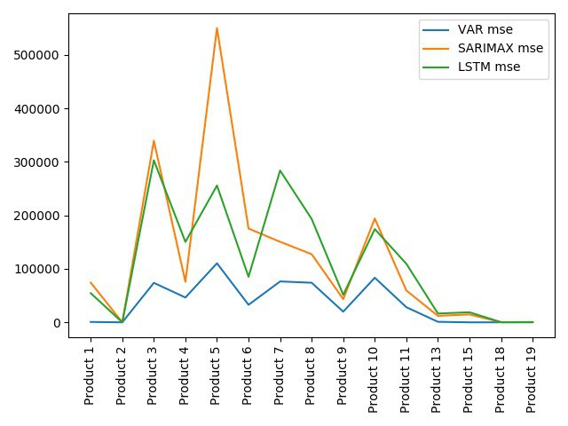

```python
Image(filename='mse.jpg')
```

As we can see the VAR has better performances than the others.

##### NB:

According to the first goal, twentytwo weeks are the time lenght required to forecast, thus we used as test-set, a total of twentytwo weeks.

### About

There are three folders, one for each model, inside each there is everything required to run the code, with detailed descriptions of each step.

#### SARIMAX & LSTM

After running the code, select the how many weeks to forecast (22 for the max amount), then select the desired segment and product listed. Only for LSTM instead, specify the number of times to repeat the forecast; this helps stabilize the model.

#### VAR

This model requires R Kernel in order to work.